# Bayesian Network for Cyanobacteria Abundance

Yirao Zhang

13/05/2021

## Data import

variables include dissolved oxygen(DO), solar radiation(ALLSKY_SFC_SW_DWN),precipitation(pRECTOT), pH, temperature(Temp), Total nitrogen(TN), Chlorophyll a(Chl.a), Total nitrogen to total phosphorus ratio(TNTP), Nitrate plus nitrite to ammonia ratio(NONH), Turbidity(Turb), Cyanobacteria abundance(Cyano).

```r
#data import
data<-read.csv("/Users/yiraozhang/Desktop/cyanobacteria_pgm/cyanobacterial-bloom-prediction/cyano_train.csv")
drop <- c("X","Date","sin","cos")
data<-data[,!(names(data) %in% drop)]
data$Cyano<-as.double(data$Cyano)
vars <- c("DO", "ALLSKY_SFC_SW_DWN", "PRECTOT","pH","Temp","TN","TP","Chl.a","TNTP","NONH","Turb","Cyano")
data <- data[vars]
colnames(data)<-c("DO", "Solar radiation", "Precipitation","pH","Temp","TN","TP","Chl.a","TNTP","NONH","Turb","Cyano")
head(data)
```

```
##      DO Solar radiation Precipitation   pH Temp    TN    TP Chl.a  TNTP  NONH
## 1  7.96           16.81          0.00 8.19 20.7 0.701 0.080  20.7  8.76  0.81
## 2  6.08           27.43          0.24 8.45 27.1 0.795 0.186  18.8  4.27  1.40
## 3  7.47           28.01          0.08 8.35 25.4 1.096 0.160  29.1  6.85 26.67
## 4  8.48           11.02          0.03 8.33 17.1 1.039 0.090  11.1 11.54  1.25
## 5 11.60           19.97          0.03 8.76  8.4 0.775 0.110  32.3  7.05  2.10
## 6 12.62           22.02          0.00 8.58  5.5 1.310 0.090  70.4 14.56  0.33
##   Turb Cyano
## 1 14.4 12966
## 2 18.3  1127
## 3 16.6  1437
## 4 23.3  4196
## 5 15.0     1
## 6 16.8  3232
```

## Remove highly correlated variables

```r
library(mlbench)
library(caret)
correlationMatrix <- cor(data)
highlyCorrelated <- findCorrelation(correlationMatrix, cutoff=0.7)
print(highlyCorrelated)
```

```
## [1] 1
```

```r
drop <- c("DO","NONH")
data<-data[,!(names(data) %in% drop)]
head(data)
```

```
##   Solar radiation Precipitation   pH Temp    TN    TP Chl.a  TNTP Turb Cyano
## 1           16.81          0.00 8.19 20.7 0.701 0.080  20.7  8.76 14.4 12966
## 2           27.43          0.24 8.45 27.1 0.795 0.186  18.8  4.27 18.3  1127
## 3           28.01          0.08 8.35 25.4 1.096 0.160  29.1  6.85 16.6  1437
## 4           11.02          0.03 8.33 17.1 1.039 0.090  11.1 11.54 23.3  4196
## 5           19.97          0.03 8.76  8.4 0.775 0.110  32.3  7.05 15.0     1
## 6           22.02          0.00 8.58  5.5 1.310 0.090  70.4 14.56 16.8  3232
```

## Normality check by histograms

linear Gaussian Bayesian networks rest on the following assumptions:  
1. every node follows a normal distribution;  
2. nodes without any parent, known as root nodes, are described by the respective marginal distributions;  
3. the conditioning effect of the parent nodes is given by an additive linear term in the mean, and does not affect the variance. In other words, each node has a variance that is specific to that node and does not depend on the values of the parents;  
4. the local distribution of each node can be equivalently expressed as a Gaussian linear model which includes an intercept and the node’s parents as explanatory variables, without any interaction term. Here we checked whether the nodes follow normal distributions via histograms.

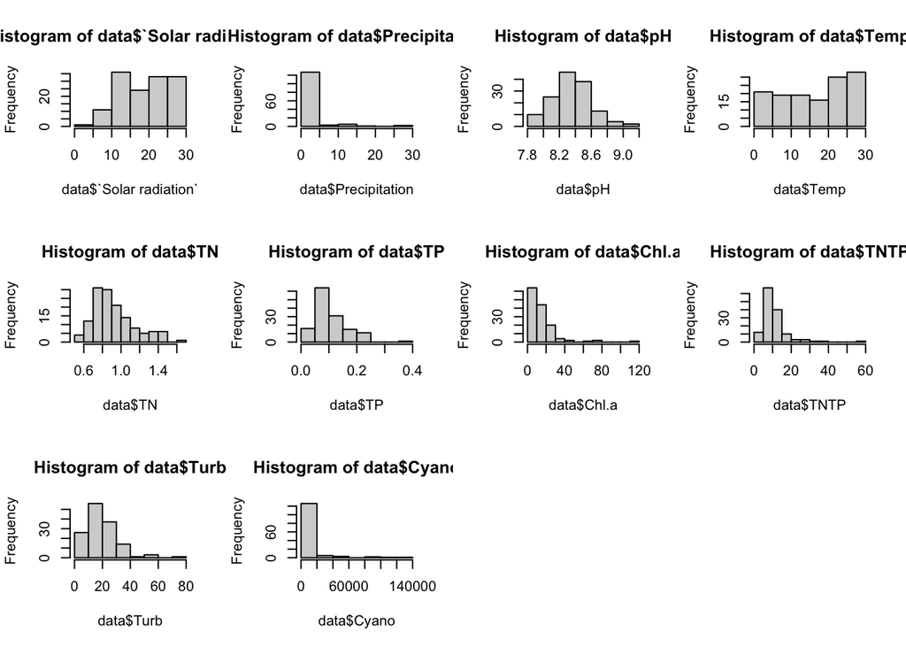

```r
par(mfrow = c(3, 4))
hist(data$`Solar radiation`)
hist(data$Precipitation)
hist(data$pH)
hist(data$Temp)
hist(data$TN)
hist(data$TP)
hist(data$Chl.a)
hist(data$TNTP)
hist(data$Turb)
hist(data$Cyano)
```

## Log-transform variables

To make the variables normaly distributed, log transform TN, TP, Chl.a, Turb, pH, TNTP and Cyano.

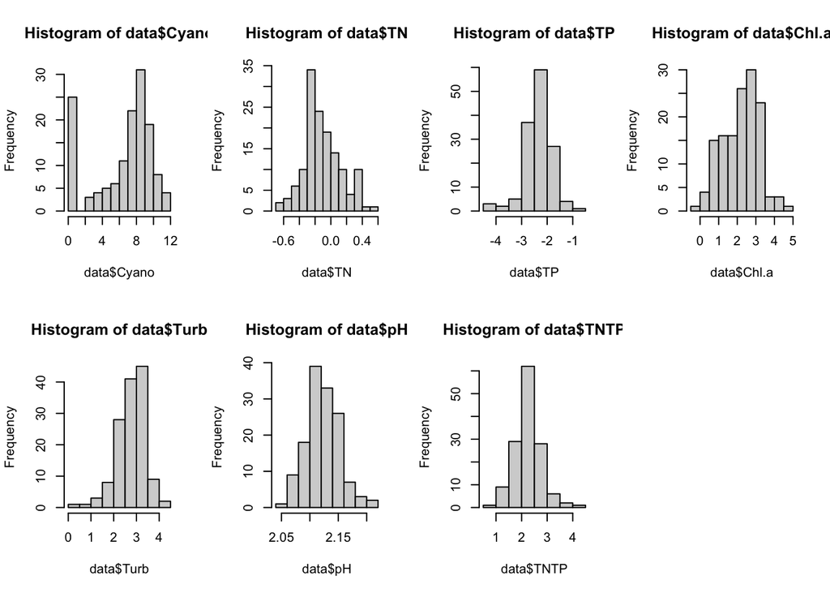

```r
data$Cyano<-log(data$Cyano)
data$TN<-log(data$TN)
data$TP<-log(data$TP)
data$Chl.a<-log(data$Chl.a)
data$Turb<-log(data$Turb)
data$pH<-log(data$pH)
data$TNTP<-log(data$TNTP)
par(mfrow = c(2,4))
hist(data$Cyano)
hist(data$TN)
hist(data$TP)
hist(data$Chl.a)
hist(data$Turb)
hist(data$pH)
hist(data$TNTP)
```

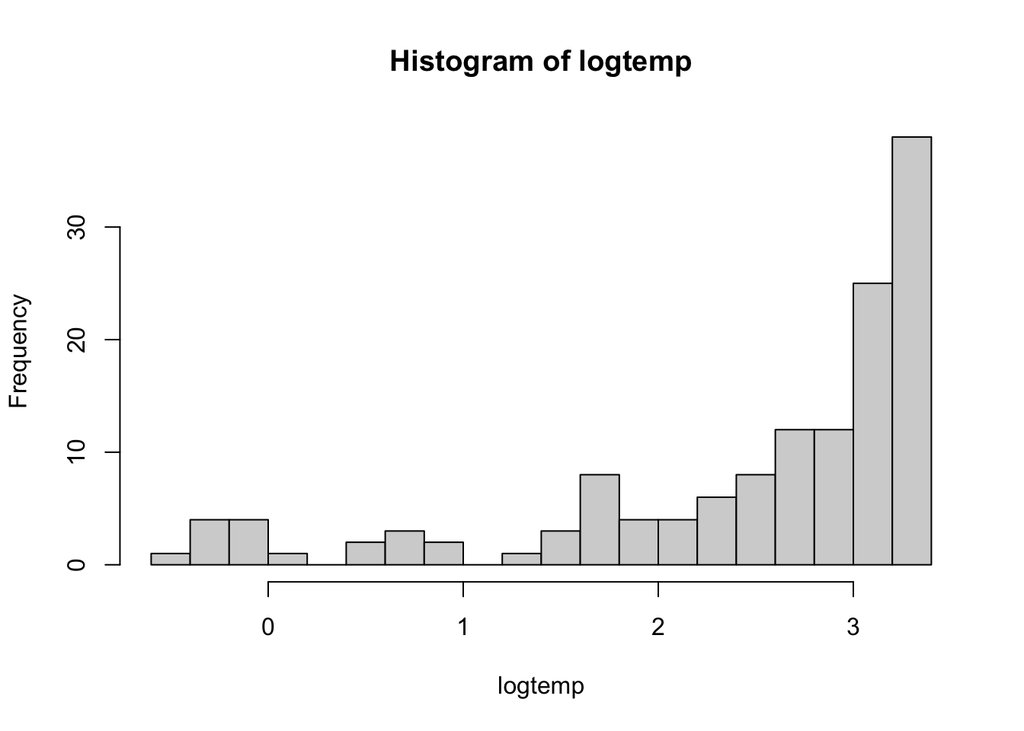

```r
logtemp<-log(data$Temp)
hist(logtemp, breaks=20)
```

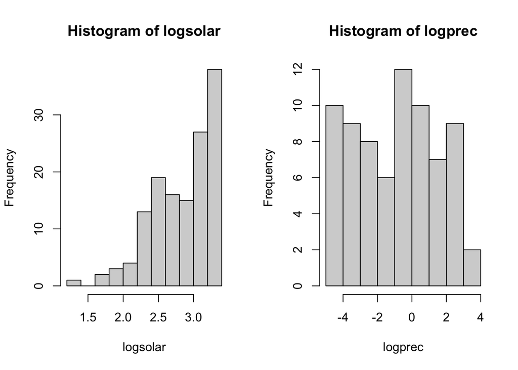

```r
#assume it to be normal(left half)
logsolar<-log(data$`Solar radiation`)
logprec<-log(data$Precipitation)
par(mfrow = c(1,2))
hist(logsolar)
hist(logprec)
```

After being log transformed, solar radiation, precipitation, cyanobacteria still are non-normal distributed. We set the solar radiation, precipitation nodes as parent nodes such that their distribution does not influence the outcome.

## Structure learning with **bnlearn**

bnlearn used tabu search to find the Bayesian network structure. We set the blacklist to force the exclusion of specific arcs (arcs that do not make sense) from the network.

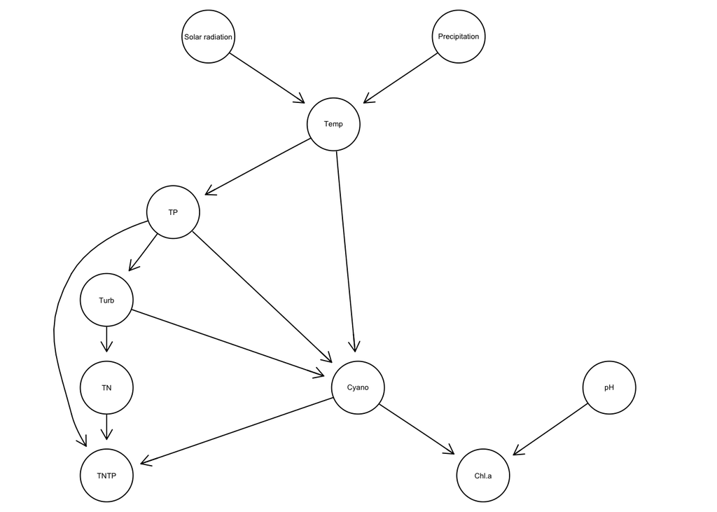

```r
library(bnlearn)
library(Rgraphviz)
bl = matrix(c("pH","Precipitation","Precipitation","pH"), ncol = 2, byrow = TRUE)
net1<-tabu(data, blacklist = bl)
graphviz.plot(net1)
```

## Fitted training data to the structure The parameters of each of the node can be learned.

```r
fitted<-bn.fit(net1, data)
fitted
```

```
##
##   Bayesian network parameters
##
##   Parameters of node Solar radiation (Gaussian distribution)
##
## Conditional density: Solar radiation
## Coefficients:
## (Intercept)
##    18.66232
## Standard deviation of the residuals: 6.805153
##
##   Parameters of node Precipitation (Gaussian distribution)
##
## Conditional density: Precipitation
## Coefficients:
## (Intercept)
##    1.516812
## Standard deviation of the residuals: 4.323501
##
##   Parameters of node pH (Gaussian distribution)
##
## Conditional density: pH
## Coefficients:
## (Intercept)
##     2.12312
## Standard deviation of the residuals: 0.0292206
##
##   Parameters of node Temp (Gaussian distribution)
##
## Conditional density: Temp | Solar radiation + Precipitation
## Coefficients:
##     (Intercept)  Solar radiation    Precipitation
##      -0.7489722        0.8833805        0.4337859
## Standard deviation of the residuals: 6.59364
##
##   Parameters of node TN (Gaussian distribution)
##
## Conditional density: TN | Turb
## Coefficients:
## (Intercept)         Turb
```

[output cut: 27 more lines]

```
##   Parameters of node Turb (Gaussian distribution)
##
## Conditional density: Turb | TP
## Coefficients:
## (Intercept)           TP
##   4.6614864    0.8016521
## Standard deviation of the residuals: 0.4337393
##
##   Parameters of node Cyano (Gaussian distribution)
##
## Conditional density: Cyano | Temp + TP + Turb
## Coefficients:
## (Intercept)         Temp           TP         Turb
##   3.5377974    0.1775259   -1.9990454   -1.6775381
## Standard deviation of the residuals: 3.016379
```

## Import test set and transform test data

```r
test<-read.csv("/Users/yiraozhang/Desktop/cyanobacteria_pgm/cyanobacterial-bloom-prediction/cyano_test.csv")
drop <- c("X","Date","sin","cos")
test<-test[,!(names(test) %in% drop)]
test$Cyano<-as.double(test$Cyano)
vars <- c("DO", "ALLSKY_SFC_SW_DWN", "PRECTOT","pH","Temp","TN","TP","Chl.a","TNTP","NONH","Turb","Cyano")
test <- test[vars]
colnames(test)<-c("DO", "Solar radiation", "Precipitation","pH","Temp","TN","TP","Chl.a","TNTP","NONH","Turb","Cyano")
drop <- c("DO","NONH")
test<-test[,!(names(data) %in% drop)]
test$Cyano<-log(test$Cyano)
test$TN<-log(test$TN)
test$TP<-log(test$TP)
test$Chl.a<-log(test$Chl.a)
test$Turb<-log(test$Turb)
test$pH<-log(test$pH)
test$TNTP<-log(test$TNTP)
head(test)
```

```
##      DO Solar radiation Precipitation       pH Temp          TN        TP
## 1 13.78            6.47          0.02 2.080691  1.6 -0.08664781 -2.525729
## 2 14.64           10.37          0.00 2.161022  0.5 -0.43078292 -3.218876
## 3  7.65           29.70          0.84 2.127041 25.4 -0.10425002 -2.385967
## 4  6.75           27.20          0.02 2.110213 24.8 -0.06827884 -2.302585
## 5 10.21           12.80          0.00 2.138889 11.1 -0.37106368 -2.659260
## 6 14.64           14.15          0.00 2.066863  3.7 -0.26396555 -4.199705
##      Chl.a     TNTP NONH      Turb    Cyano
## 1 1.740466 2.438863 5.30 2.1972246 0.000000
## 2 2.610070 2.788093 0.33 1.4816045 6.469250
## 3 2.639057 2.281361 1.33 2.3513753 8.163086
## 4 2.406945 2.234306 7.29 2.8033604 5.111988
## 5 3.254243 2.288486 0.67 2.8564702 8.660081
## 6 2.985682 3.935740 2.67 0.3364722 7.288244
```

## Model validation

*In Bayesian statistics, performance assessment is often done by using posterior simulation (Gelman, 2003; Gelman et al., 1996, 2014) because a Bayesian model results in probability distributions of model parameters, rather than point estimates. Consequently, the comparison of a predicted value and an observed value becomes a comparison of a probability distribution and an observation. We use the Bayesian posterior model to produce probability distributions of important quantities derived from the model (posterior predictive distributions) and compare these distributions to the respective observed values. In our example, we evaluated our model by using the posterior model, updated by a subset of the data from the set-aside river, to predict DIN and QHEI (not included inthe updating process). The comparison of the posterior predictive distributions and the observed values (Figs. 7 and 8) can often reveal weakness of the model and lead to strategies for model improvement.*  
(Qian, S. S., & Miltner, R. J. (2015). A continuous variable Bayesian networks model for water quality modeling: A case study of setting nitrogen criterion for small rivers and streams in Ohio, USA. Environmental Modelling & Software, 69, 14-22.)

```r
pred = predict(fitted, "Cyano", test)
cbind(pred, test[, "Cyano"])
```

```
##             pred
##  [1,]  5.1849571  0.000000
##  [2,]  7.5757912  6.469250
##  [3,]  8.8720897  8.163086
##  [4,]  7.8406682  5.111988
##  [5,]  6.0324789  8.660081
##  [6,] 12.0255995  7.288244
##  [7,]  3.8660079  7.330405
##  [8,]  4.5851691  5.513429
##  [9,] 10.1571877 10.107937
## [10,]  7.2700477  0.000000
## [11,]  7.4627140  6.936343
## [12,]  7.5788769  3.091042
## [13,]  6.7081713 10.947644
## [14,]  5.6863903  6.487684
```

[output cut: 33 more lines]

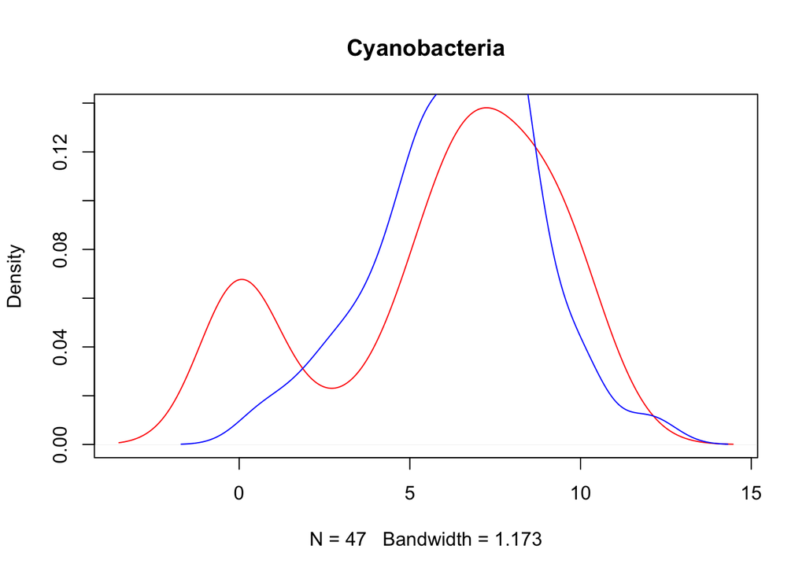

```r
plot(density(test$Cyano), col="red", main="Cyanobacteria")
lines(density(pred), col="blue")
```

From the kde plot, we can see the log-cyano data include a lot of zeros, and does not follow a normal distribution, but when the log-cyano data are not floating around zero, our model has pretty good performance.

## Problems

1. Learned structure contains some arcs that do not make sense.
2. How to deal with non-normal distribution of cyanobacteria? Gaussian mixture models(tried but failed)?
3. How is the performance of the model with limited input data(e.g. only know weather data)? Havent tried yet.